# 如何讀取政府開放資料? (以新北市人口統計資料為例)

gcchen

2019/5/10

#### 資料來源：政府資料開放平台 data.gov.tw

#### 資料名稱：新北市人口統計資料

#### 資料欄位：612,263 筆 具有 6 個變數的資料集

ver $\alpha 1.0$

以下是一系列範例程式的步驟，說明如何將下載的csv檔讀取並做後續應用。 注意實際操作時，讀取檔案的路徑可能要重新調整:

```r
ntp <- read.csv("C:\\Users\\User\\Downloads\\新北市人口統計資訊_0008534750841870883628.csv",header=T)
```

看看資料集的維度(dimension) :

```r
dim(ntp)
```

```
## [1] 612263      6
```

看看資料集的摘要統計 :

```r
summary(ntp)
```

```
##     AreaName           Year            Month             Male
##  五股區 : 21210   Min.   : 90.00   Min.   : 1.000   Min.   :   0.0
##  石碇區 : 21110   1st Qu.: 94.00   1st Qu.: 3.000   1st Qu.:  48.0
##  八里區 : 21109   Median : 98.00   Median : 6.000   Median : 181.0
##  三芝區 : 21109   Mean   : 98.22   Mean   : 6.416   Mean   : 650.6
##  三重區 : 21109   3rd Qu.:103.00   3rd Qu.: 9.000   3rd Qu.: 828.0
##  三峽區 : 21109   Max.   :107.00   Max.   :12.000   Max.   :6071.0
##  (Other):485507                                     NA's   :1
##      Female            Age
##  Min.   :   0   0歲      :  6063
##  1st Qu.:  43   100歲以上:  6062
##  Median : 175   10歲     :  6062
##  Mean   : 657   11歲     :  6062
##  3rd Qu.: 819   12歲     :  6062
##  Max.   :5749   13歲     :  6062
##  NA's   :1      (Other)  :575890
```

看看資料集的前六筆：

```r
head(ntp)
```

```
##   AreaName Year Month Male Female  Age
## 1   八里區  105    10  303    284 43歲
## 2   八里區  105    10  310    301 44歲
## 3   八里區  105    10  285    281 45歲
## 4   八里區  105    10  313    361 46歲
## 5   八里區  105    10  310    344 47歲
## 6   八里區  105    10  333    334 48歲
```

看看變數 AreaName 有幾種水準(類別)

```r
levels(ntp$AreaName)
```

```
##  [1] "八里區" "三芝區" "三重區" "三峽區" "土城區" "中和區" "五股區"
##  [8] "平溪區" "永和區" "石門區" "石碇區" "汐止區" "坪林區" "板橋區"
## [15] "林口區" "金山區" "泰山區" "烏來區" "貢寮區" "淡水區" "深坑區"
## [22] "新店區" "新莊區" "瑞芳區" "萬里區" "樹林區" "雙溪區" "蘆洲區"
## [29] "鶯歌區"
```

看看變數 Age 有幾種水準(類別)

```r
levels(ntp$Age)
```

```
##   [1] "0歲"       "100歲以上" "10歲"      "11歲"      "12歲"
##   [6] "13歲"      "14歲"      "15歲"      "16歲"      "17歲"
##  [11] "18歲"      "19歲"      "1歲"       "20歲"      "21歲"
##  [16] "22歲"      "23歲"      "24歲"      "25歲"      "26歲"
##  [21] "27歲"      "28歲"      "29歲"      "2歲"       "30歲"
##  [26] "31歲"      "32歲"      "33歲"      "34歲"      "35歲"
##  [31] "36歲"      "37歲"      "38歲"      "39歲"      "3歲"
##  [36] "40歲"      "41歲"      "42歲"      "43歲"      "44歲"
##  [41] "45歲"      "46歲"      "47歲"      "48歲"      "49歲"
##  [46] "4歲"       "50歲"      "51歲"      "52歲"      "53歲"
##  [51] "54歲"      "55歲"      "56歲"      "57歲"      "58歲"
##  [56] "59歲"      "5歲"       "60歲"      "61歲"      "62歲"
##  [61] "63歲"      "64歲"      "65歲"      "66歲"      "67歲"
##  [66] "68歲"      "69歲"      "6歲"       "70歲"      "71歲"
##  [71] "72歲"      "73歲"      "74歲"      "75歲"      "76歲"
##  [76] "77歲"      "78歲"      "79歲"      "7歲"       "80歲"
##  [81] "81歲"      "82歲"      "83歲"      "84歲"      "85歲"
##  [86] "86歲"      "87歲"      "88歲"      "89歲"      "8歲"
##  [91] "90歲"      "91歲"      "92歲"      "93歲"      "94歲"
##  [96] "95歲"      "96歲"      "97歲"      "98歲"      "99歲"
## [101] "9歲"
```

看看變數 Year 有幾種水準(類別)，發現R將其視為數值資料 (所以“沒水準”)

```r
levels(ntp$Year)
```

因此，將變數 Year 調整為因子(factor)資料， 重新看看變數 Year 有幾種水準(類別)

```r
levels(as.factor(ntp$Year))
```

```
##  [1] "90"  "91"  "92"  "93"  "94"  "95"  "96"  "97"  "98"  "99"  "100"
## [12] "101" "102" "103" "104" "105" "106" "107"
```

看看變數 Month 有幾種水準(類別)，發現R將其視為數值資料 (所以“沒水準”)

```r
levels(ntp$Month)
```

因此，將變數 Month 調整為因子(factor)資料， 重新看看變數 Month 有幾種水準(類別)

```r
levels(as.factor(ntp$Month))
```

```
##  [1] "1"  "2"  "3"  "4"  "5"  "6"  "7"  "8"  "9"  "10" "11" "12"
```

每次都要用 `ntp$變數名稱` 來呼叫變數有點麻煩， 所以利用 `attach(ntp)` 指令方便使用 ntp 資料集的各項變數：

```r
attach(ntp)
```

接下來就可以用較簡單的方式，取出八里區的男性資料： (不必再用 `ntp$Male[ntp$AreaName=="八里區"]` )  
不過因為取出的資料太多，故此處省略不印出。

```r
Male[AreaName=="八里區"]
```

接下來縮小範圍，取出八里區105年的男性資料：

```r
Male[AreaName=="八里區" & Year=="105"]
```

```
##    [1] 303 310 285 313 310 333 318 351 337 364 349 376 342 344 293 279 272
##   [18] 271 266 224 233 213 165 156 168 131  84  91  77  80  81  80  74  72
##   [35]  66  54  45  41  42  35  36  51  36  34  29  26  25  13  11  11   7
##   [52]   6  10   2   2   6   0   3 171 189 306 313 323 323 356 332 366 355
##   [69] 366 341 345 306 267 274 283 255 231 230 220 176 152 170 131  87  94
##   [86]  79  76 176 194 155 171 191 163 127 174 155 131 155 134 130 181 174
##  [103] 242 273 238 264 266 311 315 311 328 270 295 326 256 258 258 233 287
##  [120] 301 285 317 297 290 317 292 313 311 160 187 157 215 167 133 159 163
##  [137] 150 154 132 129 152 181 200 255 261 234 260 307 293 322 337 271 289
##  [154] 318 262 275 263 220 281 288 301 310 305 293 303 303 308 308 315 281
##  [171] 278 305 306 289 330 306 308 350 346 354 367 356 352 334 299 280 275
##  [188] 287 271 227 229 221 186 155 174 137  91  89  72  90  79  79  86  69
##  [205]  78  46  49  46  43  43  37  45  38  37  33  32  26  16  14  10   5
##  [222]  10   9   5   1   8   1   1   2 164 183 149 216 165 133 159 165 149
##  [239] 161 131 124 147 180 204 248 259 238 256 307 298 324 331 275 288 312
```

[output cut: 57 more lines]

資料還是有點太多，接下來再縮小範圍，取出八里區105年43歲的男性、女性資料：

```r
Male[AreaName=="八里區" & Year=="105" & Age=="43歲"]
```

```
##  [1] 303 305 300 293 292 296 301 302 305 297 299 289
```

```r
Female[AreaName=="八里區" & Year=="105" & Age=="43歲"]
```

```
##  [1] 284 302 290 292 293 292 298 292 293 285 277 259
```

然後將資料賦值予變數 aa、bb

```r
aa <- Male[AreaName=="八里區" & Year=="105" & Age=="43歲"]
bb <- Female[AreaName=="八里區" & Year=="105" & Age=="43歲"]
```

透過變數 aa，繪製八里區105年43歲男性人數變化折線圖

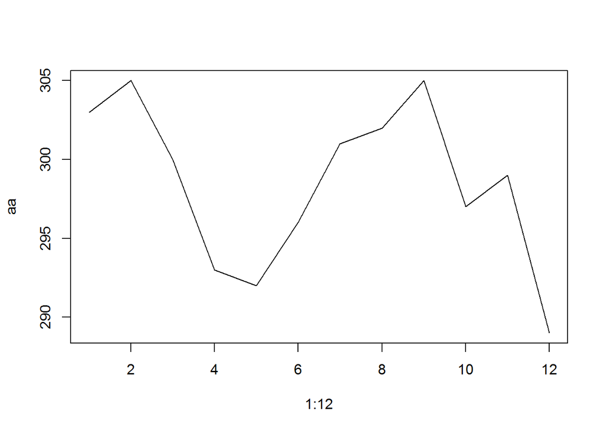

```r
plot(1:12,aa,type="l")
```

再加上女性資料(重新調整y軸的範圍以符合完整顯示的需求)

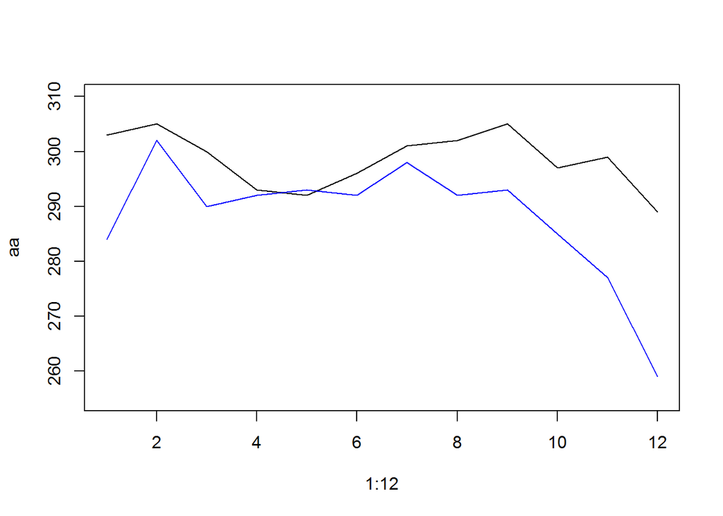

```r
plot(1:12,aa,type="l",ylim=c(255,310))
lines(1:12,bb,type="l",col="blue")
```

- 計算八里區105年43歲男性人數12個月之總和(是否有意義?)

```r
sum(Male[AreaName=="八里區" & Year=="105" & Age=="43歲"])
```

```
## [1] 3582
```

- 計算八里區105年43歲男性人數平均

```r
mean(Male[AreaName=="八里區" & Year=="105" & Age=="43歲"])
```

```
## [1] 298.5
```

- 按照區域計算男性平均人數

```r
x1 <- by(Male ,AreaName , mean)
x1
```

```
## AreaName: 八里區
## [1] 170.5608
## --------------------------------------------------------
## AreaName: 三芝區
## [1] 120.0268
## --------------------------------------------------------
## AreaName: 三重區
## [1] 1910.87
## --------------------------------------------------------
## AreaName: 三峽區
## [1] 503.3524
## --------------------------------------------------------
## AreaName: 土城區
## [1] 1175.083
## --------------------------------------------------------
## AreaName: 中和區
## [1] 2013.794
## --------------------------------------------------------
## AreaName: 五股區
## [1] 393.2515
## --------------------------------------------------------
## AreaName: 平溪區
## [1] 30.03382
## --------------------------------------------------------
## AreaName: 永和區
## [1] 1102.859
## --------------------------------------------------------
## AreaName: 石門區
## [1] 63.07902
## --------------------------------------------------------
## AreaName: 石碇區
## [1] NA
## --------------------------------------------------------
## AreaName: 汐止區
## [1] 903.7324
## --------------------------------------------------------
## AreaName: 坪林區
## [1] 35.89583
## --------------------------------------------------------
## AreaName: 板橋區
```

[output cut: 31 more lines]

```
## --------------------------------------------------------
## AreaName: 萬里區
## [1] 106.8234
## --------------------------------------------------------
## AreaName: 樹林區
## [1] 855.365
## --------------------------------------------------------
## AreaName: 雙溪區
## [1] 52.27088
## --------------------------------------------------------
## AreaName: 蘆洲區
## [1] 937.4325
## --------------------------------------------------------
## AreaName: 鶯歌區
## [1] 430.3552
```

- 按照區域計算女性平均人數

```r
x2 <- by(Female , AreaName , mean)
x2
```

```
## AreaName: 八里區
## [1] 165.4202
## --------------------------------------------------------
## AreaName: 三芝區
## [1] 111.0504
## --------------------------------------------------------
## AreaName: 三重區
## [1] 1916.227
## --------------------------------------------------------
## AreaName: 三峽區
## [1] 479.7016
## --------------------------------------------------------
## AreaName: 土城區
## [1] 1173.604
## --------------------------------------------------------
## AreaName: 中和區
## [1] 2054.439
## --------------------------------------------------------
## AreaName: 五股區
## [1] 380.9084
## --------------------------------------------------------
## AreaName: 平溪區
## [1] 24.08522
## --------------------------------------------------------
## AreaName: 永和區
## [1] 1187.825
## --------------------------------------------------------
## AreaName: 石門區
## [1] 56.11289
## --------------------------------------------------------
## AreaName: 石碇區
## [1] NA
## --------------------------------------------------------
## AreaName: 汐止區
## [1] 917.0179
## --------------------------------------------------------
## AreaName: 坪林區
## [1] 28.03832
## --------------------------------------------------------
## AreaName: 板橋區
```

[output cut: 31 more lines]

```
## --------------------------------------------------------
## AreaName: 萬里區
## [1] 100.5807
## --------------------------------------------------------
## AreaName: 樹林區
## [1] 839.9717
## --------------------------------------------------------
## AreaName: 雙溪區
## [1] 44.25776
## --------------------------------------------------------
## AreaName: 蘆洲區
## [1] 952.4572
## --------------------------------------------------------
## AreaName: 鶯歌區
## [1] 418.6798
```

- 各區男女性平均人數按照列方式並呈

```r
x12 <- rbind(x1,x2)
x12
```

```
##      八里區   三芝區   三重區   三峽區   土城區   中和區   五股區   平溪區
## x1 170.5608 120.0268 1910.870 503.3524 1175.083 2013.794 393.2515 30.03382
## x2 165.4202 111.0504 1916.227 479.7016 1173.604 2054.439 380.9084 24.08522
##      永和區   石門區 石碇區   汐止區   坪林區   板橋區   林口區   金山區
## x1 1102.859 63.07902     NA 903.7324 35.89583 2691.672 376.9825 110.5957
## x2 1187.825 56.11289     NA 917.0179 28.03832 2734.544 383.3354 108.3986
##      泰山區   烏來區   貢寮區   淡水區   深坑區   新店區   新莊區   瑞芳區
## x1 365.4095 27.65550 70.04652 681.5105 112.6109 1414.470 1950.556 218.7571
## x2 361.1433 26.83666 64.80937 713.9239 109.5095 1466.556 1993.016 208.4633
##      萬里區   樹林區   雙溪區   蘆洲區   鶯歌區
## x1 106.8234 855.3650 52.27088 937.4325 430.3552
## x2 100.5807 839.9717 44.25776 952.4572 418.6798
```

- 各區男女性平均人數按照欄方式並呈

```r
x12a <- cbind(x1,x2)
x12a
```

```
##                x1         x2
## 八里區  170.56076  165.42015
## 三芝區  120.02677  111.05041
## 三重區 1910.86968 1916.22720
## 三峽區  503.35241  479.70160
## 土城區 1175.08286 1173.60448
## 中和區 2013.79350 2054.43901
## 五股區  393.25149  380.90839
## 平溪區   30.03382   24.08522
## 永和區 1102.85883 1187.82534
## 石門區   63.07902   56.11289
## 石碇區         NA         NA
## 汐止區  903.73244  917.01786
## 坪林區   35.89583   28.03832
## 板橋區 2691.67189 2734.54413
## 林口區  376.98252  383.33535
## 金山區  110.59567  108.39855
## 泰山區  365.40949  361.14326
## 烏來區   27.65550   26.83666
## 貢寮區   70.04652   64.80937
## 淡水區  681.51054  713.92387
## 深坑區  112.61088  109.50945
## 新店區 1414.46961 1466.55630
## 新莊區 1950.55649 1993.01563
## 瑞芳區  218.75707  208.46326
## 萬里區  106.82339  100.58075
## 樹林區  855.36496  839.97167
## 雙溪區   52.27088   44.25776
## 蘆洲區  937.43252  952.45725
## 鶯歌區  430.35520  418.67976
```

- 去掉男、女性資料NA值後，各區男女性平均人數按照欄方式並呈

```r
y1 <- by(Male ,AreaName , mean ,na.rm=T)
y2 <- by(Female ,AreaName , mean ,na.rm=T)
y12a <- cbind(y1,y2)
y12a
```

```
##                y1         y2
## 八里區  170.56076  165.42015
## 三芝區  120.02677  111.05041
## 三重區 1910.86968 1916.22720
## 三峽區  503.35241  479.70160
## 土城區 1175.08286 1173.60448
## 中和區 2013.79350 2054.43901
## 五股區  393.25149  380.90839
## 平溪區   30.03382   24.08522
## 永和區 1102.85883 1187.82534
## 石門區   63.07902   56.11289
## 石碇區   43.04984   34.18674
## 汐止區  903.73244  917.01786
## 坪林區   35.89583   28.03832
## 板橋區 2691.67189 2734.54413
## 林口區  376.98252  383.33535
## 金山區  110.59567  108.39855
## 泰山區  365.40949  361.14326
## 烏來區   27.65550   26.83666
## 貢寮區   70.04652   64.80937
## 淡水區  681.51054  713.92387
## 深坑區  112.61088  109.50945
## 新店區 1414.46961 1466.55630
## 新莊區 1950.55649 1993.01563
## 瑞芳區  218.75707  208.46326
## 萬里區  106.82339  100.58075
## 樹林區  855.36496  839.97167
## 雙溪區   52.27088   44.25776
## 蘆洲區  937.43252  952.45725
## 鶯歌區  430.35520  418.67976
```

用 `class(y12a)` 得知 y12a 為矩陣型態

```r
class(y12a)
```

```
## [1] "matrix"
```

- 將資料轉成 dataframe格式

```r
rn<-as.vector(rownames(y12a))
y12a <- data.frame(rn,y12a)
names(y12a)
```

```
## [1] "rn" "y1" "y2"
```

- 修改調整變數名稱

```r
names(y12a) <- c("區域","男性","女性")
rownames(y12a)<-1:29
y12a
```

```
##      區域       男性       女性
## 1  八里區  170.56076  165.42015
## 2  三芝區  120.02677  111.05041
## 3  三重區 1910.86968 1916.22720
## 4  三峽區  503.35241  479.70160
## 5  土城區 1175.08286 1173.60448
## 6  中和區 2013.79350 2054.43901
## 7  五股區  393.25149  380.90839
## 8  平溪區   30.03382   24.08522
## 9  永和區 1102.85883 1187.82534
## 10 石門區   63.07902   56.11289
## 11 石碇區   43.04984   34.18674
## 12 汐止區  903.73244  917.01786
## 13 坪林區   35.89583   28.03832
## 14 板橋區 2691.67189 2734.54413
## 15 林口區  376.98252  383.33535
## 16 金山區  110.59567  108.39855
## 17 泰山區  365.40949  361.14326
## 18 烏來區   27.65550   26.83666
## 19 貢寮區   70.04652   64.80937
## 20 淡水區  681.51054  713.92387
## 21 深坑區  112.61088  109.50945
## 22 新店區 1414.46961 1466.55630
## 23 新莊區 1950.55649 1993.01563
## 24 瑞芳區  218.75707  208.46326
## 25 萬里區  106.82339  100.58075
## 26 樹林區  855.36496  839.97167
## 27 雙溪區   52.27088   44.25776
## 28 蘆洲區  937.43252  952.45725
## 29 鶯歌區  430.35520  418.67976
```

- 利用 `attach(y12a)` 指令方便使用 y12a 資料集的各項變數
- 引入ggplot2 套件
- 依據不同區域繪製男性平均人數
- 依據不同區域繪製女性平均人數

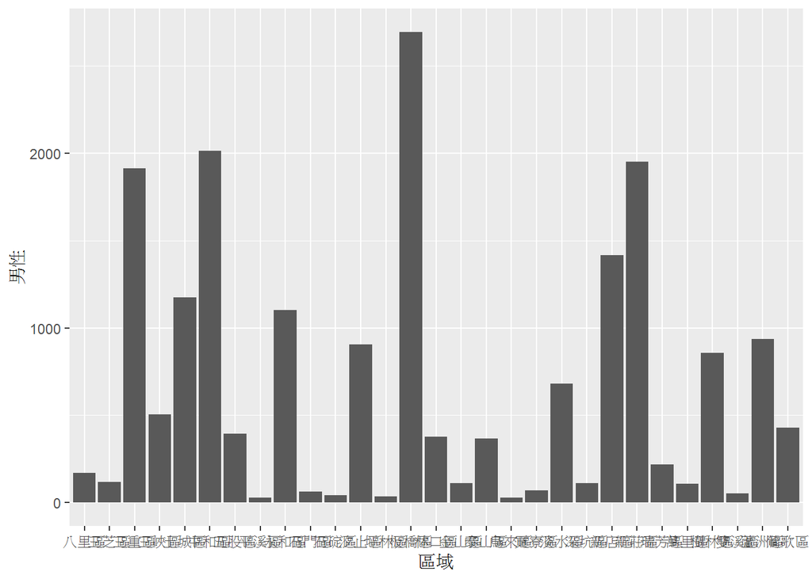

```r
attach(y12a)
library(ggplot2)
ggplot(y12a,aes(x=區域,y=男性))+geom_bar(stat="identity")
```

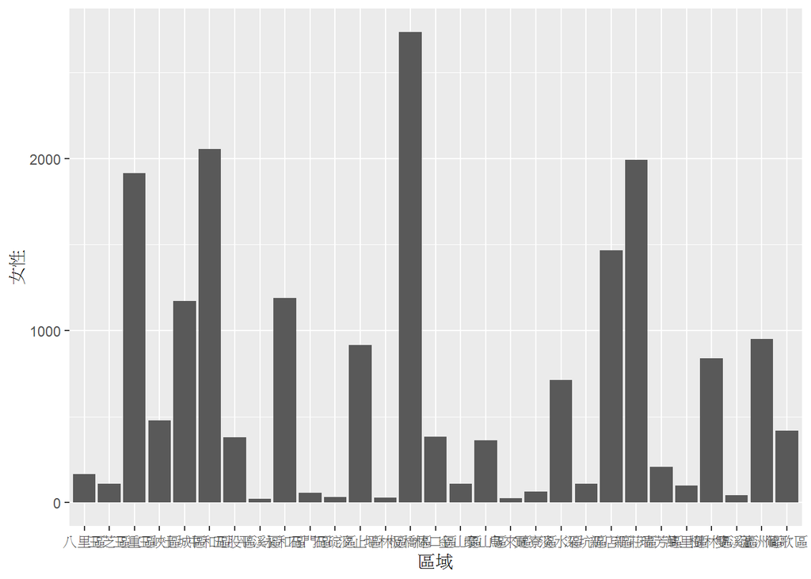

```r
ggplot(y12a,aes(x=區域,y=女性))+geom_bar(stat="identity")
```

從 50% 比率的水平線，可看出有哪些區域的男性比率高過女性 (90-107年整體平均)

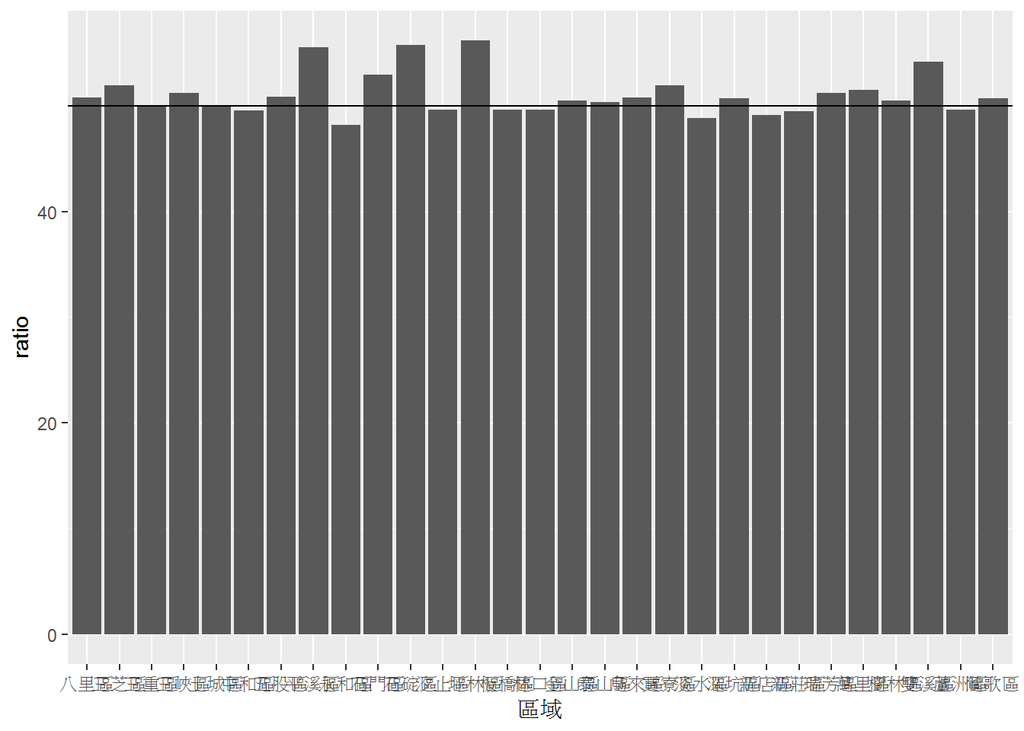

```r
library(plyr)
y12a$ratio <-  with(y12a,(男性/(男性+女性))*100)
ggplot(y12a,aes(x=區域,y=ratio))+geom_bar(stat="identity")+geom_hline(yintercept=50)
```